# Projet IF36

Analyse des accidents de la route en France

## Présentation du projet

Dans le cadre de ce projet, nous avons exploité un jeu de données consolidé issu du fichier BAAC (Bulletin d’Analyse des Accidents Corporels). Les données sources proviennent du jeu de données officiel **[Bases de données annuelles des accidents corporels de la circulation routière - 2005 à 2024](https://www.data.gouv.fr/datasets/bases-de-donnees-annuelles-des-accidents-corporels-de-la-circulation-routiere-annees-de-2005-a-2024)**, disponible sur la plateforme data.gouv.fr.

Notre fichier principal `accidents_2020_2024.csv` a été construit pour l’analyse en fusionnant, pour chaque année de 2020 à 2024, les 4 tables BAAC suivantes : - `usagers` - `vehicules` - `lieux` - `caracteristiques`

L’objectif est de mener une exploration visuelle des accidents corporels en cherchant des relations entre la gravité, le contexte routier, les profils d’usagers, les véhicules et la temporalité. Nous voulons identifier ce qui semble augmenter le risque d’accident grave, tout en restant critiques sur les limites de la donnée.

## Structure et nature des données

Le fichier CSV contient **689 434 lignes** et **56 variables**.

Les correspondances complètes se trouvent dans le pdf ‘Descriptions_des_bases_de_données_annuelles.pdf’. Nous avons décider de ne pas toutes les mettre pour ne surcharger les tableaux déjà conséquents.

### 1. Identifiants (7 variables)

| Variable | Note (Libellé) | Type | Description |
| --- | --- | --- | --- |
| **Num_Acc** | Identifiant Accident | VARCHAR | Identifiant unique de l’accident. |
| **id_vehicule** | Identifiant Véhicule | VARCHAR | Identifiant unique du véhicule. |
| **num_veh** | Numéro Véhicule | VARCHAR | Identifiant relatif (A01, B01…). |
| **num_veh_veh** | Numéro Véhicule (Lien) | VARCHAR | Doublon technique de `num_veh`. |
| **id_usager** | Identifiant Usager | VARCHAR | Identifiant unique de l’usager. |
| **annee_dataset** | Année Source | INTEGER | Année du fichier d’origine. |
| **adr** | Adresse | VARCHAR | Adresse postale simplifiée. |

*Note : Ces variables peuvent être surpprimer car inutiles dans l’annalyse*

### 2. Variables temporelles (5 variables)

| Variable | Note (Libellé) | Type | Format / Valeurs |
| --- | --- | --- | --- |
| **an** | Année | INTEGER | Format YYYY. |
| **mois** | Mois | INTEGER | 1 à 12. |
| **jour** | Jour | INTEGER | 1 à 31. |
| **hrmn** | Heure et Minute | VARCHAR | Format HH:MM. |
| **an_nais** | Année naissance | INTEGER | Année de naissance de l’usager. |

### 3. Profil et état de l’usager (12 variables)

| Variable | Note (Libellé) | Type | Valeurs |
| --- | --- | --- | --- |
| **place** | Place occupée | INTEGER | 1:Conducteur, 2:Passager AV, 10:Piéton… |
| **catu** | Catégorie usager | INTEGER | 1:Conducteur, 2:Passager, 3:Piéton. |
| **grav** | Gravité | INTEGER | 1:Indemne, 2:Tué, 3:Hospit, 4:Léger. |
| **sexe** | Sexe | INTEGER | 1:Masculin, 2:Féminin. |
| **trajet** | Motif déplacement | INTEGER | 1:Travail, 5:Loisirs, 9:Autre. |
| **secu1** | Équipement 1 | INTEGER | 1:Ceinture, 2:Casque, 9:Non utilisé. |
| **secu2** | Équipement 2 | INTEGER | Idem secu1. |
| **secu3** | Équipement 3 | INTEGER | Idem secu1. |
| **locp** | Localis. piéton | INTEGER | 1:Sur chaussée, 5:Trottoir… |
| **actp** | Action piéton | INTEGER | 3:Traversant, 6:Statique… |
| **etatp** | État piéton | INTEGER | 1:Seul, 2:Accompagné, 3:En groupe. |
| **occutc** | Occupants TC | INTEGER | Nb d’occupants dans les transports en commun. |

### 4. Caractéristiques du véhicule (7 variables)

| Variable | Note (Libellé) | Type | Valeurs |
| --- | --- | --- | --- |
| **senc** | Sens circulation | INTEGER | 1:Sens croissant, 2:Sens inverse. |
| **catv** | Catégorie véhicule | INTEGER | 07:VL, 01:Vélo, 33:Moto… |
| **obs** | Obstacle fixe | INTEGER | 1:Véh. stationné, 2:Arbre, 10:Mur… |
| **obsm** | Obstacle mobile | INTEGER | 1:Piéton, 2:Véhicule, 6:Animal. |
| **choc** | Point de choc | INTEGER | 1:Avant, 2:Arrière, 3:Droit, 4:Gauche. |
| **manv** | Manœuvre | INTEGER | 1:Sans changement, 15:Tourne G… |
| **motor** | Motorisation | INTEGER | 1:Hydrocarbures, 3:Élec, 4:Hydrogène. |

*Note : Là aussi des variables sont inutiles et peuvent donc être surpprimées*

### 5. Localisation et contexte (10 variables)

| Variable | Note (Libellé) | Type | Valeurs |
| --- | --- | --- | --- |
| **dep** | Département | VARCHAR | Code (ex: 75, 2A). |
| **com** | Commune | VARCHAR | Code INSEE commune. |
| **agg** | Agglomération | INTEGER | 1:Hors agglo, 2:En agglo. |
| **int** | Intersection | INTEGER | 1:Hors int., 6:Giratoire… |
| **lum** | Lumière | INTEGER | 1:Jour, 5:Nuit avec écl. |
| **atm** | Météo | INTEGER | 1:Normale, 2:Pluie, 4:Neige… |
| **col** | Type collision | INTEGER | 1:Frontale, 3:Côté, 6:Autre. |
| **lat** | Latitude | FLOAT | Coordonnée |
| **long** | Longitude | FLOAT | Coordonnée |
| **situ** | Situation | INTEGER | 1:Sur chaussée, 3:Accotement, 4:Trottoir. |

### 6. Infrastructure et voie (16 variables)

| Variable | Note (Libellé) | Type | Valeurs |
| --- | --- | --- | --- |
| **catr** | Catégorie route | INTEGER | 1:Autoroute, 3:Départementale… |
| **voie** | Nom de la voie | VARCHAR | Nom de la rue ou route. |
| **v1** | Numéro route | VARCHAR | Numéro de la voie. |
| **v2** | Indice route | VARCHAR | Indice alphanumérique de la voie. |
| **circ** | Régime circulation | INTEGER | 1:Sens unique, 2:Bidirectionnel. |
| **nbv** | Nb de voies | INTEGER | Nombre total de voies. |
| **vosp** | Voie réservée | INTEGER | 1:Piste cyclable, 2:Voie bus. |
| **prof** | Profil route | INTEGER | 1:Plat, 2:Pente, 3:Sommet. |
| **pr** | Point de repère | VARCHAR | Numéro du PR. |
| **pr1** | Distance au PR | VARCHAR | Distance en mètres au PR. |
| **plan** | Tracé en plan | INTEGER | 1:Rectiligne, 2:Courbe. |
| **lartpc** | Largeur TPC | FLOAT | Largeur du terre-plein central. |
| **larrout** | Largeur chaussée | FLOAT | Largeur de la route (hors accotements). |
| **surf** | État surface | INTEGER | 1:Normale, 2:Mouillée, 7:Verglacée. |
| **infra** | Aménagement | INTEGER | 1:Souterrain, 3:Échangeur, 5:Pont. |
| **vma** | Vitesse autorisée | INTEGER | Vitesse max en km/h. |

*Note : Les valeurs `-1` ou `0` indiquent une donnée non renseignée ou non applicable.*

### Question Max

#### **Les accidents en agglomération sont-ils différents de ceux hors agglomération ?** (en terme de gravité et volume)

Pour répondre à cette question j’ai décidé de faire un barplot (`geom_bar`) une barre pour les accidents en agglomération et une autre pour ceux hors agglomération. De plus, avec la fonction `positon = stack` on peut observer la gravité de l’accident sur les passagers/conducteurs.

```r
print(head(df))
```

```
##    Num_Acc place catu grav sexe an_nais trajet secu1 locp actp senc catv obs
## 1 2.02e+11     1    1    1    1    1983      5     1   -1   -1    1    7   0
## 2 2.02e+11     1    1    3    1    1982      5     2   -1   -1    1   33   0
## 3 2.02e+11     1    1    1    1    1997      1     8   -1   -1    3    7   0
## 4 2.02e+11    10    3    4    1    1967      5     0    3    3    3    7   0
## 5 2.02e+11     1    1    1    1    1985      0     1   -1   -1    1    7   0
## 6 2.02e+11     4    2    3    1    2014      0     8   -1   -1    1    7   0
##   obsm choc manv motor jour mois   an     hrmn lum dep   com agg int atm col
## 1    2    2   15     1    7    3 2020 16:55:00   1  91 91657   2   3   1   3
## 2    2    1    2     1    7    3 2020 16:55:00   1  91 91657   2   3   1   3
## 3    1    2   26     1    7    3 2020 08:35:00   2  91 91657   2   9   7   6
## 4    1    2   26     1    7    3 2020 08:35:00   2  91 91657   2   9   7   6
## 5    2    1    1     1    7    3 2020 13:30:00   1  91 91174   2   2   1   3
## 6    2    1    1     1    7    3 2020 13:30:00   1  91 91174   2   2   1   3
##             lat         long catr circ nbv prof plan surf infra situ vma
## 1 48,7053500000 2,4384100000    4    2   2    1    1    1     0    1  50
## 2 48,7053500000 2,4384100000    4    2   2    1    1    1     0    1  50
## 3 48,6900000000 2,4100000000    4    2   2    1    3    1     0    1  50
## 4 48,6900000000 2,4100000000    4    2   2    1    3    1     0    1  50
## 5 48,6106700000 2,4758200000    4   -1   2    1    1    1     0    1  50
## 6 48,6106700000 2,4758200000    4   -1   2    1    1    1     0    1  50
```

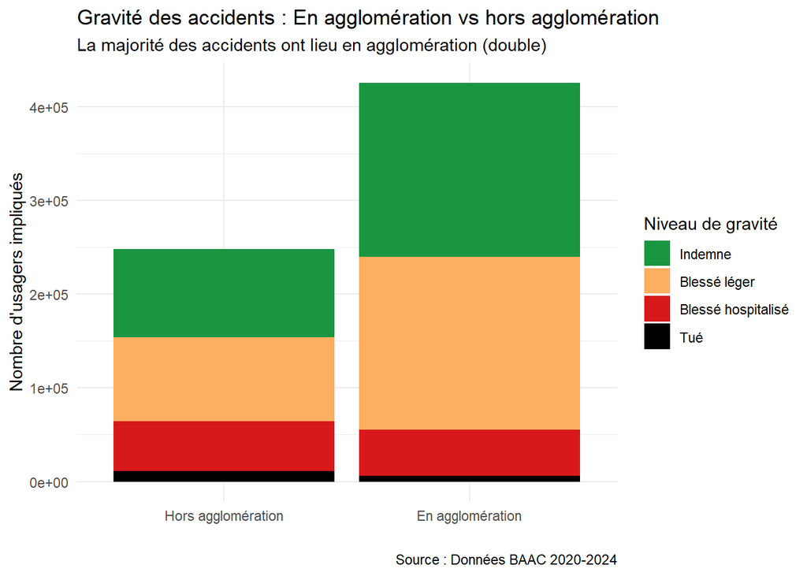

```r
# On crée d'abord le tableau nettoyé et on crée des catégories
df_plot <- df %>%
  filter(agg %in% c(1, 2), grav %in% c(1, 2, 3, 4)) %>% # permet de ne pas prendre les NA
  mutate(
    Agglomeration = factor(agg,
                           levels = c(1, 2), # On transforme les numéros en catégories distinctes et en leur donnant un ordre choisi
                           labels = c("Hors agglomération", "En agglomération")),
    Gravite = factor(grav,
                     levels = c(1, 4, 3, 2),
                     # Ici on choisit un ordre spécifique de gravité
                     labels = c("Indemne", "Blessé léger", "Blessé hospitalisé", "Tué"))
  )

ggplot(df_plot, aes(x = Agglomeration, fill = Gravite)) +
  geom_bar(position = "stack") + # Stack permet de ne garder les proportions (plus intérressant dans le cas d'une comparaison de volume)
  scale_fill_manual(values = c("Indemne" = "#1a9641",
                               "Blessé léger" = "#fdae61",
                               "Blessé hospitalisé" = "#d7191c",
                               "Tué" = "#000000")) +
  labs(
    title = "Gravité des accidents : En agglomération vs hors agglomération",
    subtitle = "La majorité des accidents ont lieu en agglomération (double)",
    x = "",
    y = "Nombre d'usagers impliqués",
    fill = "Niveau de gravité",
    caption = "Source : Données BAAC 2020-2024"
  ) +
  theme_minimal()
```

De ce premier graphique, on peut observer une nette différence quant à la quantité d’accidents en ville. Presque **le double** d’accidents ont lieu en ville comparé aux accidents hors agglomération. Néanmoins, on voit aussi que les accidents ont tendances à être plus grave hors agglomération. Pour observer ce phénomène de plus près, voici un second graphique similaire au premier mais en étudiant seulement les accidents graves (blessés hospitalisés et tués).

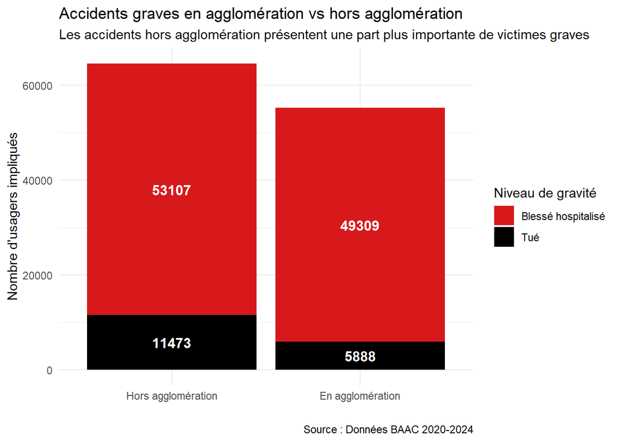

```r
# Deuxième df en prennant cette fois-ci uniquement les bléssés et tués
df_plot <- df %>%
  filter(agg %in% c(1, 2), grav %in% c(3, 2)) %>% # On ne prend que les bléssés et tué
  mutate(
    Agglomeration = factor(agg,
                           levels = c(1, 2), # On transforme les numéros en catégories distinctes et en leur donnant un ordre choisi
                           labels = c("Hors agglomération", "En agglomération")),
    Gravite = factor(grav,
                     levels = c(3, 2),
                     # Ici on choisit un ordre spécifique de gravité
                     labels = c("Blessé hospitalisé", "Tué"))
  )

ggplot(df_plot, aes(x = Agglomeration, fill = Gravite)) +
  geom_bar(position = "stack") + # Stack permet de ne garder les proportions (plus intérressant dans le cas d'une comparaison de volume)
  stat_count(geom = "text",
             aes(label = after_stat(count)),
             position = position_stack(vjust = 0.5),
             color = "white", size = 4, fontface = "bold") +
  scale_fill_manual(values = c("Blessé hospitalisé" = "#d7191c",
                               "Tué" = "#000000")) +
  labs(
    title = "Accidents graves en agglomération vs hors agglomération",
    subtitle = "Les accidents hors agglomération présentent une part plus importante de victimes graves",
    x = "",
    y = "Nombre d'usagers impliqués",
    fill = "Niveau de gravité",
    caption = "Source : Données BAAC 2020-2024"
  ) +
  theme_minimal()
```

### Question Alex

#### **Quel est l’impact de la météo (pluie, neige, brouillard) sur les accidents ?**

Pour répondre à cette question, je propose d’utiliser trois graphiques complémentaires :

- un diagramme en barres du nombre d’accidents par météo, pour analyser la fréquence ;
- un diagramme en barres du taux d’accidents graves, pour évaluer la gravité ;
- un diagramme en barres empilées à 100 %, pour observer la répartition de la gravité des usagers selon la météo.

##### Création d’un jeu de données enrichi avec des variables météo et gravité

```r
tableau_resume <- meteo_resume %>%
  mutate(
    `Nombre d'accidents` = number(n_accidents),
    `Part des accidents` = percent(part_accidents),
    `Taux d'accidents graves` = percent(taux_gravite),
    `Taux d'accidents mortels` = percent(taux_mortalite)
  ) %>%
  select(
    `Condition meteorologique` = meteo,
    `Nombre d'accidents`,
    `Part des accidents`,
    `Taux d'accidents graves`,
    `Taux d'accidents mortels`
  )
kable(tableau_resume, align = c("l", "r", "r", "r", "r"))
```

| Condition meteorologique | Nombre d’accidents | Part des accidents | Taux d’accidents graves | Taux d’accidents mortels |
| --- | --- | --- | --- | --- |
| Normale | 212 311 | 79,0% | 36,0% | 5,6% |
| Pluie legere | 30 036 | 11,2% | 29,3% | 4,9% |
| Pluie forte | 6 135 | 2,3% | 36,6% | 6,5% |
| Neige / grele | 806 | 0,3% | 42,3% | 6,7% |
| Brouillard / fumee | 1 947 | 0,7% | 54,8% | 13,4% |
| Vent fort / tempete | 791 | 0,3% | 56,3% | 10,1% |
| Temps eblouissant | 4 745 | 1,8% | 53,8% | 7,7% |
| Temps couvert | 10 637 | 4,0% | 34,0% | 6,4% |
| Autre | 1 209 | 0,5% | 48,1% | 9,4% |

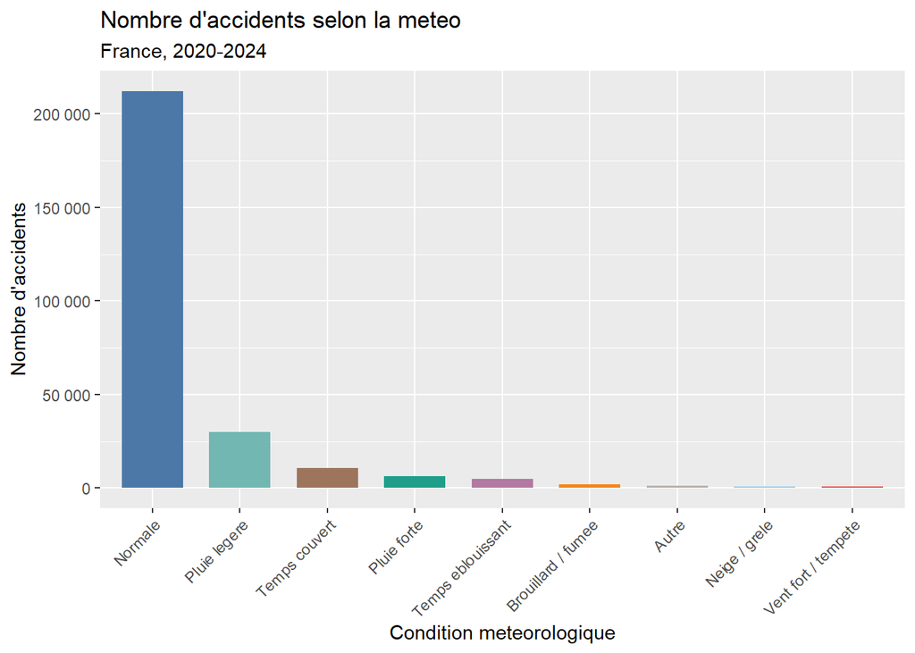

```r
ggplot(meteo_resume, aes(x = reorder(meteo, -n_accidents), y = n_accidents, fill = meteo)) +
  geom_col(width = 0.7, show.legend = FALSE) +
  scale_y_continuous(labels = number) +
  scale_fill_manual(values = meteo_palette, drop = FALSE) +
  labs(
    title = "Nombre d'accidents selon la meteo",
    subtitle = "France, 2020-2024",
    x = "Condition meteorologique",
    y = "Nombre d'accidents"
  ) +
  theme(axis.text.x = element_text(angle = 45, vjust = 1, hjust = 1))
```

Ce graphique montre que la majorité des accidents se produit sous une météo normale. Cela ne signifie pas que ces conditions sont les plus dangereuses, mais plutôt qu’elles sont les plus fréquentes au moment des déplacements. À l’inverse, les situations de pluie, de brouillard ou de neige apparaissent moins souvent en nombre absolu, mais elles peuvent être associées à des accidents plus graves. Il faut donc distinguer ici la fréquence des accidents et leur gravité.

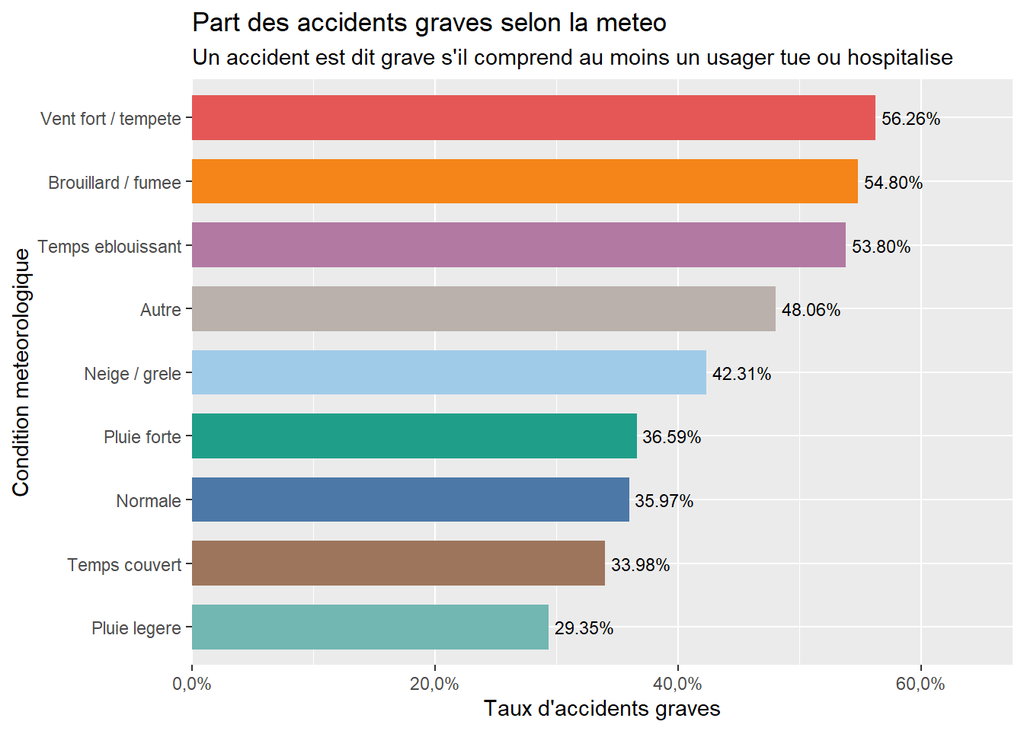

```r
ggplot(meteo_resume, aes(x = reorder(meteo, taux_gravite), y = taux_gravite, fill = meteo)) +
  geom_col(width = 0.7, show.legend = FALSE) +
    geom_text(
    aes(label = scales::percent(taux_gravite)),
    hjust = -0.1,
    size = 3
  ) +
  scale_y_continuous(labels = percent, expand = expansion(mult = c(0, 0.2))) +
  scale_fill_manual(values = meteo_palette, drop = FALSE) +
  coord_flip() +
  labs(
    title = "Part des accidents graves selon la meteo",
    subtitle = "Un accident est dit grave s'il comprend au moins un usager tue ou hospitalise",
    x = "Condition meteorologique",
    y = "Taux d'accidents graves"
  )
```

Ce graphique montre que la part des accidents graves varie sensiblement selon les conditions météorologiques. Les taux les plus élevés apparaissent en cas de vent fort / tempête (56,3 %), de brouillard / fumée (54,8 %) et de temps éblouissant (53,8 %), ce qui suggère qu’une visibilité dégradée ou des conditions atmosphériques plus difficiles augmentent surtout la sévérité des accidents lorsqu’ils se produisent. À l’inverse, la pluie légère présente le taux le plus faible (29,3 %), tandis que la météo normale se situe à un niveau intermédiaire (36,0 %). Il faut toutefois interpréter avec prudence les catégories les moins fréquentes, car leurs effectifs sont plus réduits.

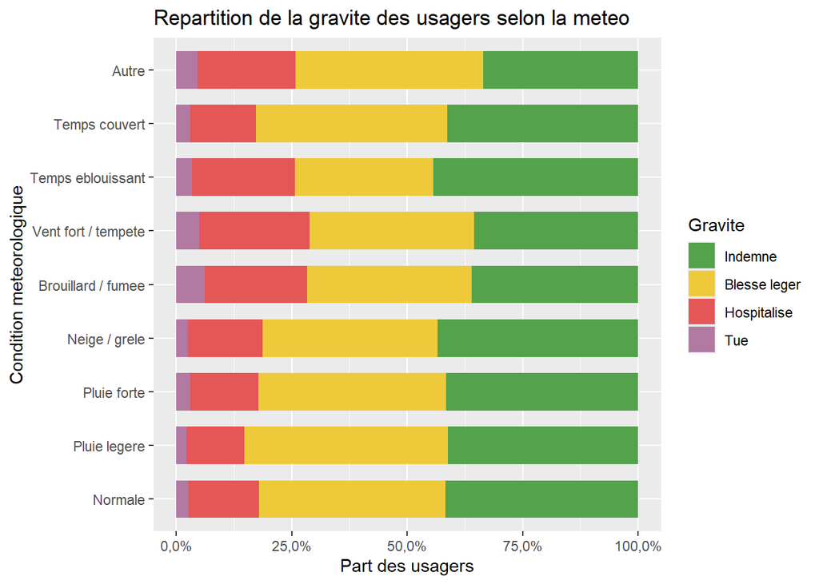

```r
ggplot(profil_usagers, aes(x = meteo, y = part, fill = gravite_usager)) +
  geom_col(position = "fill", width = 0.7) +
  scale_y_continuous(labels = percent) +
  scale_fill_manual(values = c(
    "Indemne" = "#54A24B",
    "Blesse leger" = "#EECA3B",
    "Hospitalise" = "#E45756",
    "Tue" = "#B279A2"
  )) +
  labs(
    title = "Repartition de la gravite des usagers selon la meteo",
    x = "Condition meteorologique",
    y = "Part des usagers",
    fill = "Gravite"
  ) +
  coord_flip()
```

Ce graphique complete l’analyse precedente en s’interessant non plus aux accidents, mais a la gravite des usagers impliques. On observe que sous vent fort / tempete, brouillard / fumee et temps eblouissant, la part d’usagers tues ou hospitalises est plus elevee, ce qui confirme une gravite plus importante dans ces conditions. À l’inverse, sous pluie legere, la structure est moins severe, avec une plus grande part d’usagers indemnes ou legerement blesses. Il faut toutefois rester prudent pour les categories les moins frequentes, comme « Autre » ou le vent fort / la tempete, car leurs effectifs sont plus faibles.

### Question Paul-Louis

#### Les motos ont-elles un taux de gravité plus élevé ?

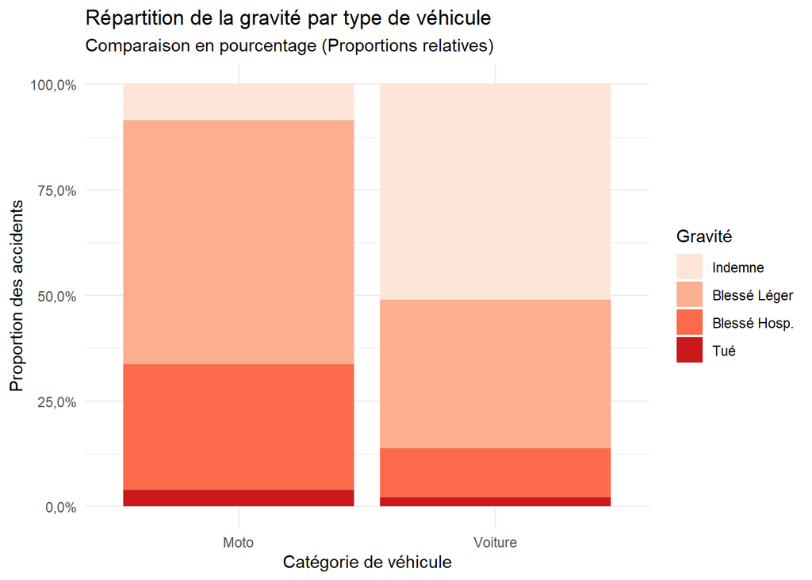

```r
df_plot <- df %>%
  #On filtre pour ne garder que Voitures (7) et Motos/Scooters
  filter(catv %in% c(7, 30, 31, 32, 33, 34)) %>%

  #On transforme les chiffres en mots explicites
  mutate(
    Type_Vehicule = ifelse(catv == 7, "Voiture", "Moto"),
    Gravite_Label = case_when(
      grav == 1 ~ "Indemne",
      grav == 2 ~ "Tué",
      grav == 3 ~ "Blessé Hosp.",
      grav == 4 ~ "Blessé Léger"
    ),

    Gravite_Label = factor(Gravite_Label,
                           levels = c("Indemne", "Blessé Léger", "Blessé Hosp.", "Tué"))
  )

library(scales)

ggplot(df_plot, aes(x = Type_Vehicule, fill = Gravite_Label)) +
  geom_bar(position = "fill") +
  scale_y_continuous(labels = percent) +
  scale_fill_brewer(palette = "Reds") +
  labs(title = "Répartition de la gravité par type de véhicule",
       subtitle = "Comparaison en pourcentage (Proportions relatives)",
       x = "Catégorie de véhicule",
       y = "Proportion des accidents",
       fill = "Gravité") +
  theme_minimal()
```

Le graphique montre très clairement que les accidents de moto sont proportionnellement beaucoup plus graves que les accidents de voiture. La probabilité de s’en sortir indemne est drastiquement plus faible en deux-roues.

### Question Marega

#### **Le type de route influence-t-il la gravité des accidents ?**

#### Objectif de l’analyse :

L’objectif est d’identifier les infrastructures routières où les accidents présentent la plus forte sévérité. En normalisant les données par type de route (proportion), nous cherchons à déterminer si le réseau routier influence intrinsèquement la gravité des chocs, indépendamment du volume de trafic global. Nous attendons de visualiser une disparité dans la répartition des niveaux de gravité, notamment pour repérer les routes affichant les taux de “Tués” ou “Blessés hospitalisés” les plus élevés.

```r
df_prop <- df %>%
  # 1. On filtre pour ne garder que les valeurs valides
  filter(catr %in% c(1, 2, 3, 4, 5, 6, 7, 9),
         grav %in% c(1, 2, 3, 4)) %>%
  mutate(
    # 2. Mise à jour des labels selon l'image fournie
    catr_label = factor(catr,
      levels = c(1, 2, 3, 4, 5, 6, 7, 9),
      labels = c("Autoroute",
                 "Route nationale",
                 "Route départementale",
                 "Voie communale",
                 "Hors réseau public",
                 "Parc de stationnement",
                 "Routes métropole",
                 "Autre")),
    # Labels de gravité conservés
    grav_label = factor(grav,
      levels = c(1, 2, 3, 4),
      labels = c("Indemne", "Tué", "Blessé hospitalisé", "Blessé léger"))
  ) %>%
  group_by(catr_label, grav_label) %>%
  summarise(n = n(), .groups = 'drop') %>%
  group_by(catr_label) %>%
  mutate(pct = n / sum(n))
```

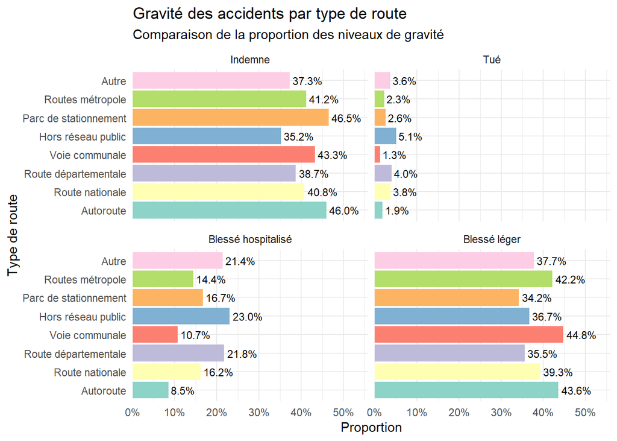

```r
ggplot(df_prop, aes(x = pct, y = reorder(catr_label, pct), fill = catr_label)) +
  geom_bar(stat = "identity") +
  # Ajout des étiquettes de pourcentage
  geom_text(
    aes(label = scales::percent(pct, accuracy = 0.1)),
    hjust = -0.1,
    size = 3
  ) +
  # Sépare par gravité
  facet_wrap(~grav_label, ncol = 2) +
  scale_x_continuous(labels = scales::percent, expand = expansion(mult = c(0, 0.2))) +
  # Couleurs distinctes pour chaque type de route
  scale_fill_brewer(palette = "Set3") +
  labs(
    title = "Gravité des accidents par type de route",
    subtitle = "Comparaison de la proportion des niveaux de gravité",
    x = "Proportion",
    y = "Type de route",
    fill = "Type de route"
  ) +
  theme_minimal() +
  theme(legend.position = "none") # Masquer la légende car les labels y_axis sont explicites
```

#### Analyse des résultats :

La décomposition par facettes permet d’isoler la gravité des accidents pour chaque type de voie.

Sur les accidents graves : On observe que les routes “Hors réseau” et les “Départementales” présentent des barres proportionnellement plus longues dans la catégorie “Hospit.” (hospitalisé) et “Tué” par rapport aux autoroutes. Cela suggère une dangerosité accrue sur ces axes, probablement liée à la configuration des routes ou aux vitesses pratiquées.

Sur les accidents moins graves : À l’inverse, les “Autoroutes” et les voies “Communales” affichent une proportion plus élevée de blessés “Léger” et d’usagers “Indemne”.

Conclusion : Ces résultats confirment une corrélation entre l’infrastructure routière et l’issue des accidents. Les réseaux secondaires (départementales et hors réseau) apparaissent comme étant les plus critiques, nécessitant une vigilance particulière comparée aux réseaux structurants comme les autoroutes qui, malgré des vitesses élevées, semblent offrir une protection relative supérieure.